# ExtraaLearn Project

```
              precision    recall  f1-score   support

           0       0.92      0.83      0.88       962
           1       0.69      0.84      0.76       422

    accuracy                           0.84      1384
   macro avg       0.81      0.84      0.82      1384
weighted avg       0.85      0.84      0.84      1384
```

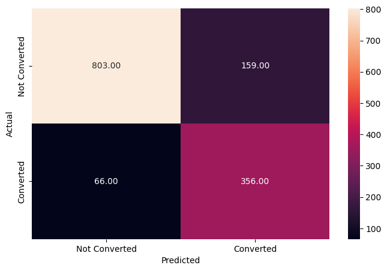

```python
# Making predictions on the test data with the tuned random forest classifier
y_pred_test4 = rf_estimator_tuned.predict(X_test)

# Using the metrics_score function to evaluate the model's performance on the test data
metrics_score(y_test, y_pred_test4)
```

Note that the tuned test dataset performs better than the tuned trained dataset in terms of precision for the class 1. The recall has reduced though by 0.03. Accuracy remains the same.

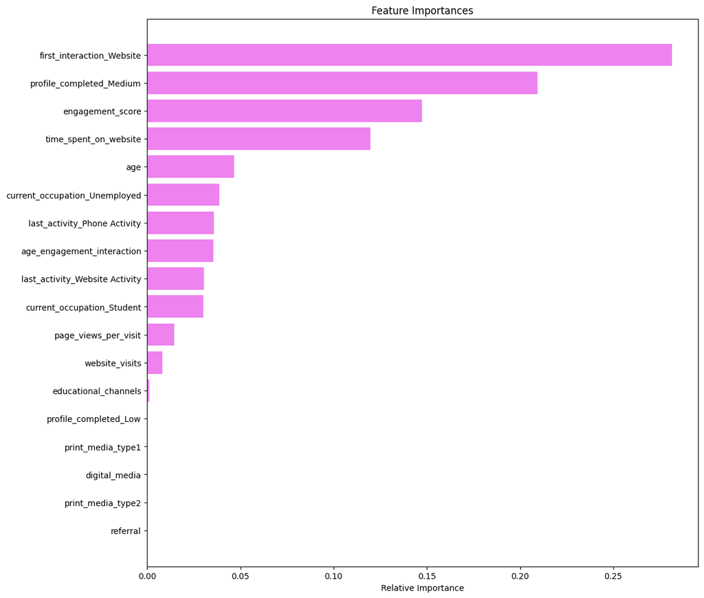

```python
importances = rf_estimator_tuned.feature_importances_

indices = np.argsort(importances)

feature_names = list(X.columns)

plt.figure(figsize = (12, 12))

plt.title('Feature Importances')

plt.barh(range(len(indices)), importances[indices], color = 'violet', align = 'center')

plt.yticks(range(len(indices)), [feature_names[i] for i in indices])

plt.xlabel('Relative Importance')

plt.show()
```

## Do we need to prune the tree?

We don't need to prune the tree when considering the random forest trees because there is built-in regularization: Random Forest inherently includes several mechanisms that prevent overfitting despite the complexity of individual trees. This is achieved through the randomness introduced by selecting different subsets of features and training examples. The ensemble method, where predictions are averaged (for regression) or voted upon (for classification), further mitigates the risk of overfitting.

However, the above is true only if we used random search instead of GridSearch. Since we used GridSearch, we have certain features that are not that important, hence we can prune the tree. To further prune the tree we can only change the tuning of individual parameters like we did before.

## Actionable Insights and Recommendations

- We saw that time_spent_on_website is the most important feature when considering the lead status in the decision tree model and the first_interaction feature is the most important in the random forest model. Since time_spent_on_website is a crucial factor, ensuring that the website is engaging, informative, and easy to navigate can encourage potential leads to spend more time exploring the content.
- The company should focus marketing efforts and budgets on the channels that have the highest lead conversion rate.
- They should focus on user feedback for designing their recommendation systems further and employ A/B testing for experimenting with different strategies.
- The insights regarding the statistical tests are visualized via graphs and commented upon as well in the document. We have used ANOVA and Chi-squared test to judge the impact of these factors.
- We have gauged the model predictions through decision trees and random forests and have visualized and commented upon its findings.
- Further we have included feature engineering (adding two new features) and performed EDA on the dataset before and after adding the features
- we have tuned the model to deal with overfitting and used classification reports to measure the precion, recall, f1 score, accuracy and confusion matrix of the variables
- we created 2 lists: a numerical one and a categorical one to proceed with our analysis on the same and have gauged the target variable wrt all the other columns through our univariate, bivariate, and multivariate analysis.
- We determined the skewness of the distributions of the numeric variables where we learnt that the age factor is skewed left. The central tendency of points, the shape and other factors.
- We also focused on important features at the end of predictive models and decided upon their pruning status.